# Default of Credit Card Clients Dataset

Sourabh Agrawal

Kaggle Task: https://www.kaggle.com/gpreda/default-of-credit-card-clients-predictive-models

## Dataset

This dataset contains information on default payments, demographic factors, credit data, history of payment, and bill statements of credit card clients in Taiwan from *April 2005* to *September 2005*.

## Variable

There are 25 variables:

1. **ID**: ID of each client
2. **LIMIT_BAL**: Amount of given credit in NT dollars (includes individual and family/supplementary credit
3. **SEX**: Gender (1=male, 2=female)
4. **EDUCATION**: (1=graduate school, 2=university, 3=high school, 4=others, 5=unknown, 6=unknown)
5. **MARRIAGE**: Marital status (1=married, 2=single, 3=others)
6. **AGE**: Age in years
7. **PAY_0**: Repayment status in September, 2005 (-1=pay duly, 1=payment delay for one month, 2=payment delay for two months, … 8=payment delay for eight months, 9=payment delay for nine months and above)
8. **PAY_2**: Repayment status in August, 2005 (scale same as above)
9. **PAY_3**: Repayment status in July, 2005 (scale same as above)
10. **PAY_4**: Repayment status in June, 2005 (scale same as above)
11. **PAY_5**: Repayment status in May, 2005 (scale same as above)
12. **PAY_6**: Repayment status in April, 2005 (scale same as above)
13. **BILL_AMT1**: Amount of bill statement in September, 2005 (NT dollar)
14. **BILL_AMT2**: Amount of bill statement in August, 2005 (NT dollar)
15. **BILL_AMT3**: Amount of bill statement in July, 2005 (NT dollar)
16. **BILL_AMT4**: Amount of bill statement in June, 2005 (NT dollar)
17. **BILL_AMT5**: Amount of bill statement in May, 2005 (NT dollar)
18. **BILL_AMT6**: Amount of bill statement in April, 2005 (NT dollar)
19. **PAY_AMT1**: Amount of previous payment in September, 2005 (NT dollar)
20. **PAY_AMT2**: Amount of previous payment in August, 2005 (NT dollar)
21. **PAY_AMT3**: Amount of previous payment in July, 2005 (NT dollar)
22. **PAY_AMT4**: Amount of previous payment in June, 2005 (NT dollar)
23. **PAY_AMT5**: Amount of previous payment in May, 2005 (NT dollar)
24. **PAY_AMT6**: Amount of previous payment in April, 2005 (NT dollar)
25. **default.payment.next.month**: Default payment (1=yes, 0=no)

## 1. Installing Packages

```r
# install.packages("plyr")
 install.packages("caret") # for sampling and confusion matrix, for CV
 install.packages("randomForest") # for using classification algo - randomForest
```

## 2. Loading Packages

```r
 library(plyr)
 library(caret)
 library(e1071)
 library(randomForest)
```

```r
# library(class)
 library(ggplot2)
 library(naniar) # for missing values
 library(corrplot)
# library(GGally)
```

## 3. Importing Dataset

```r
our.data = read.csv("data/UCI_Credit_Card.csv")
```

## 4. Preprocessing

4.1 Checking the structure of our dataset

```r
str(our.data)
```

```
## 'data.frame':    30000 obs. of  25 variables:
##  $ ID                        : int  1 2 3 4 5 6 7 8 9 10 ...
##  $ LIMIT_BAL                 : num  20000 120000 90000 50000 50000 50000 500000 100000 140000 20000 ...
##  $ SEX                       : int  2 2 2 2 1 1 1 2 2 1 ...
##  $ EDUCATION                 : int  2 2 2 2 2 1 1 2 3 3 ...
##  $ MARRIAGE                  : int  1 2 2 1 1 2 2 2 1 2 ...
##  $ AGE                       : int  24 26 34 37 57 37 29 23 28 35 ...
##  $ PAY_0                     : int  2 -1 0 0 -1 0 0 0 0 -2 ...
##  $ PAY_2                     : int  2 2 0 0 0 0 0 -1 0 -2 ...
##  $ PAY_3                     : int  -1 0 0 0 -1 0 0 -1 2 -2 ...
##  $ PAY_4                     : int  -1 0 0 0 0 0 0 0 0 -2 ...
##  $ PAY_5                     : int  -2 0 0 0 0 0 0 0 0 -1 ...
##  $ PAY_6                     : int  -2 2 0 0 0 0 0 -1 0 -1 ...
##  $ BILL_AMT1                 : num  3913 2682 29239 46990 8617 ...
##  $ BILL_AMT2                 : num  3102 1725 14027 48233 5670 ...
##  $ BILL_AMT3                 : num  689 2682 13559 49291 35835 ...
##  $ BILL_AMT4                 : num  0 3272 14331 28314 20940 ...
##  $ BILL_AMT5                 : num  0 3455 14948 28959 19146 ...
##  $ BILL_AMT6                 : num  0 3261 15549 29547 19131 ...
##  $ PAY_AMT1                  : num  0 0 1518 2000 2000 ...
##  $ PAY_AMT2                  : num  689 1000 1500 2019 36681 ...
##  $ PAY_AMT3                  : num  0 1000 1000 1200 10000 657 38000 0 432 0 ...
##  $ PAY_AMT4                  : num  0 1000 1000 1100 9000 ...
##  $ PAY_AMT5                  : num  0 0 1000 1069 689 ...
##  $ PAY_AMT6                  : num  0 2000 5000 1000 679 ...
##  $ default.payment.next.month: int  1 1 0 0 0 0 0 0 0 0 ...
```

4.2 Checking the missing value

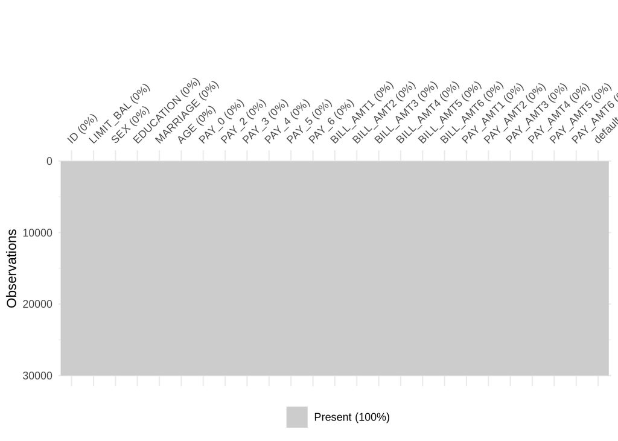

```r
vis_miss(our.data)
```

No missing data in our data set.

4.3 Renameing column **PAY_0** to **PAY_1** and default.payment.next.month as **DEFAULT**

```r
colnames(our.data)[colnames(our.data) == "PAY_0"] = "PAY_1"

colnames(our.data)[colnames((our.data)) == "default.payment.next.month"] = "DEFAULT"
```

4.4 Checking the correlation of DEFAULT variable with other numeric variables

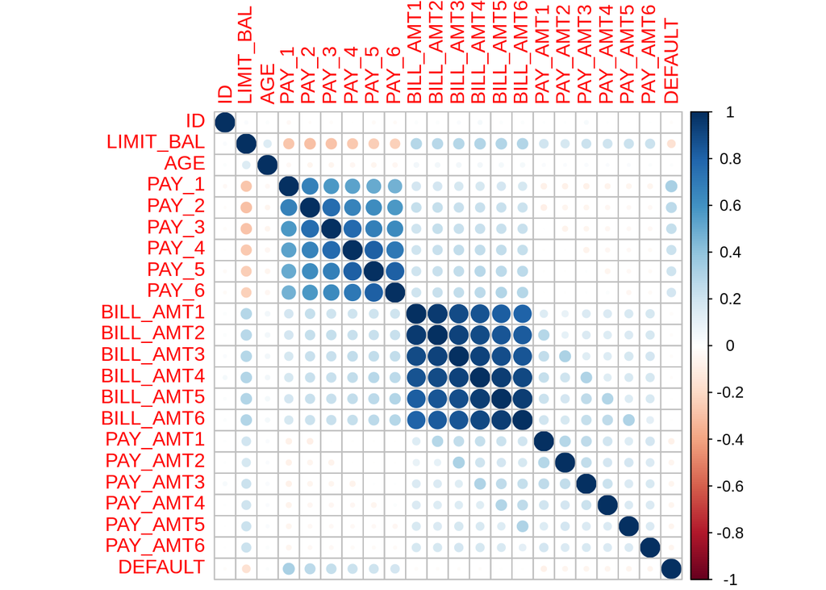

```r
# Check correlation
our.data$DEFAULT = as.numeric(our.data$DEFAULT)
r = cor(our.data[-c(3, 4, 5, 26, 27)])
corrplot(r, method = "circle")
```

4.4 Convert int variables to factors 1. DEFAULT to categorical variable

```r
our.data$DEFAULT = as.factor(our.data$DEFAULT)
```

```
2. SEX to categorical variable
```

```r
# Convert SEX to factor
our.data$SEX = as.factor(our.data$SEX)
```

4.5 Checking the distribution of ‘DEFAULT’ values

```r
table(our.data$DEFAULT)
```

```
##
##     0     1
## 23364  6636
```

## A. FUNCTIONS

A.1 calDefaultPerc - To find the Defaulter % in categorical variable

```r
calDefaultPerc = function(x, colInd, data.level){
  default_count = c()
  default_perc = c()

  for (i in 1:length(data.level)) {
    print("start of for...")
    total_count = count(x[x[colInd] == data.level[i], ], vars = "DEFAULT")
    count_def = total_count[total_count$DEFAULT == 1, 2]
    total = total_count[total_count$DEFAULT == 1, 2] + total_count[total_count$DEFAULT == 0, 2]
    print(i)
    perc = round(count_def/total * 100, digits = 2)

    default_count = c(default_count, count_def)
    default_perc = c(default_perc, perc)
    print("end of for...")
  }
  print("outer for....")
  #data.level
  length(default_count)
  length(default_perc)

  paste("data.level: ", length(data.level))
  paste("default_count: ", length(default_count))
  paste("default_perc: ", length(default_perc))

  default_perc_df = data.frame(level = data.level, default.count = default_count,
                               percentage = default_perc)
  print("data frame created....")
  return(default_perc_df)
}
```

A.2 addMaritalStatus -> new column to find customer’s marital status

```r
# Adding one feature marital status
addMaritalStatus = function(x, colInd, newColInd){
  for (i in 1: nrow(x)) {
    if(x[i, colInd] == 1){
      x[i, newColInd] = "Married"
    }
    else if (x[i, colInd] == 2) {
      x[i, newColInd] = "Not Married"
    }
    else{
      x[i, newColInd] = "Others"
    }

  }
  return(x)
}
```

A.3 calDiffBillAndPayPer -> function to calculate the remaining amount percentage

```r
# calculate diff of each row of total BILL_AMT and total PAY_AMT
calDiffBillAndPayPer = function(x, bill_amt_ind, pay_amt_ind){
  TOTAL_PAYABLE_PERC = c()

  for (i in 1:nrow(x)) {
    sum_bill_amt = sum(x[i, bill_amt_ind])
    sum_pay_amt = sum(x[i, pay_amt_ind])

    payable_amt =  sum_bill_amt - sum_pay_amt
    if(sum_bill_amt != 0){
      payable_perc = round(payable_amt / sum_bill_amt * 100, digits = 2)
    }
    else{
      payable_perc = 0.00
    }

    TOTAL_PAYABLE_PERC = c(TOTAL_PAYABLE_PERC, payable_perc)
  }
  return(TOTAL_PAYABLE_PERC)
}
```

A.4 getRemPerRange -> function to find the percentage range

```r
# function to find the range of REMAINING_AMT_PER_RANGE
getRemPerRange = function(x, colInd){
  all_per_range = c()

  for (i in 1:nrow(x)) {
    per_range = -1

    if(x[i, colInd] >=0 & x[i, colInd] <= 10)
      per_range = 0
    else if(x[i, colInd] >10 & x[i, colInd] <= 20)
      per_range = 1
    else if(x[i, colInd] >20 & x[i, colInd] <= 30)
      per_range = 2
    else if(x[i, colInd] >30 & x[i, colInd] <= 40)
      per_range = 3
    else if(x[i, colInd] >40 & x[i, colInd] <= 50)
      per_range = 4
    else if(x[i, colInd] >50 & x[i, colInd] <= 60)
      per_range = 5
    else if(x[i, colInd] >60 & x[i, colInd] <= 70)
      per_range = 6
    else if(x[i, colInd] >70 & x[i, colInd] <= 80)
      per_range = 7
    else if(x[i, colInd] >80 & x[i, colInd] <= 90)
      per_range = 8
    else if(x[i, colInd] >90 & x[i, colInd] <= 100)
      per_range = 9
    else
      per_range = -1

    all_per_range = c(all_per_range, per_range)
  }

  return(all_per_range)
}
```

A.5 getLimitBalRange -> function to find out Limit Bal range

```r
# Function to find the Limit Balance Range
getLimitBalRange = function(x, colInd){
  limit_bal_seg = c()

  for (i in 1:nrow(x)) {
    bal_seg = 0
    if (10000 >= x[i, colInd] & x[i, colInd] < 100000)
      bal_seg = 0
    else if (100000 >= x[i, colInd] & x[i, colInd] < 200000)
      bal_seg = 1
    else if (200000 >= x[i, colInd] & x[i, colInd] < 300000)
      bal_seg = 2
    else if (300000 >= x[i, colInd] & x[i, colInd] < 400000)
      bal_seg = 3
    else if (400000 >= x[i, colInd] & x[i, colInd] < 500000)
      bal_seg = 4
    else if (500000 >= x[i, colInd] & x[i, colInd] < 600000)
      bal_seg = 5
    else if (600000 >= x[i, colInd] & x[i, colInd] < 700000)
      bal_seg = 6
    else if (700000 >= x[i, colInd] & x[i, colInd] < 800000)
      bal_seg = 7
    else if (800000 >= x[i, colInd] & x[i, colInd] < 900000)
      bal_seg = 8
    else
      bal_seg = 9

    limit_bal_seg = c(limit_bal_seg, bal_seg)
  }

  return(limit_bal_seg)
}
```

## 5. Featuring

**5.1 Add one feature GENDER**

```r
our.data$GENDER = ifelse(our.data$SEX == 1, "Male", "Female")
```

5.1.2 Plotting Bar graph for GENDER

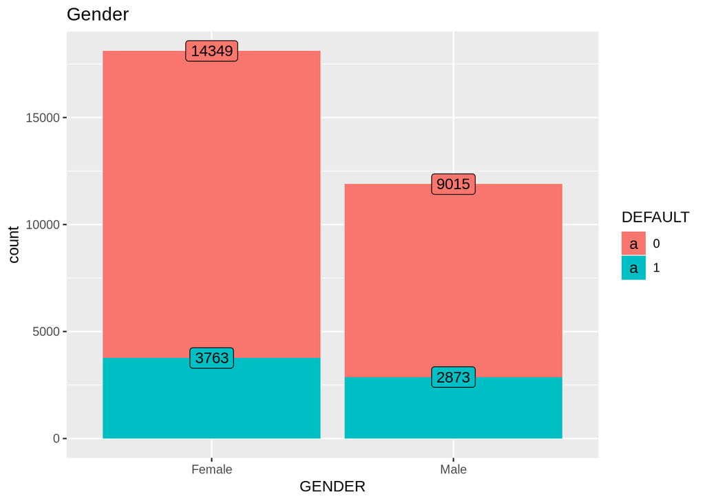

```r
# Bar Graph for gender
ggplot(data = our.data, mapping = aes(x = GENDER, fill = DEFAULT)) +
  geom_bar() +
  ggtitle("Gender") +
  stat_count(aes(label = ..count..), geom = "label")
```

**5.2 EDUCATION** 5.2.1 Merging 0, 5 and 6 to 4(others)

```r
our.data$EDUCATION = ifelse(our.data$EDUCATION == 0 |our.data$EDUCATION == 5 | our.data$EDUCATION == 6,
       4, our.data$EDUCATION)
```

5.2.2 Converting EDUCATION to categorical variable

```r
our.data$EDUCATION = as.factor(our.data$EDUCATION)
```

5.2.3 Plotting Bar graph for EDUCATION

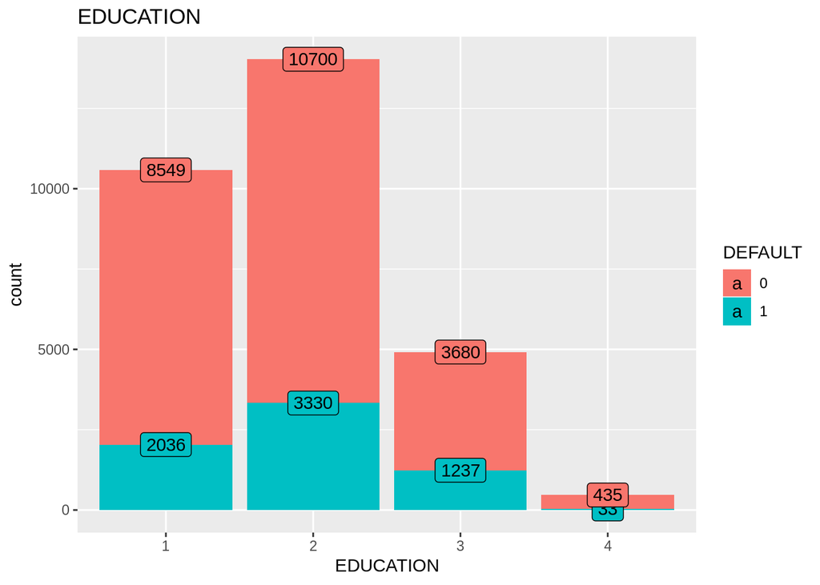

```r
ggplot(data = our.data, mapping = aes(x = EDUCATION, fill = DEFAULT)) +
  geom_bar() +
  ggtitle("EDUCATION") +
  stat_count(aes(label = ..count..), geom = "label")
```

5.2.4 Find out Default % in all education type

```r
default_count_perc = calDefaultPerc(x = our.data, colInd = 4,
                                    data.level = levels(our.data$EDUCATION))
```

5.2.4.1 Plotting a Bar graph to show defaulters %age

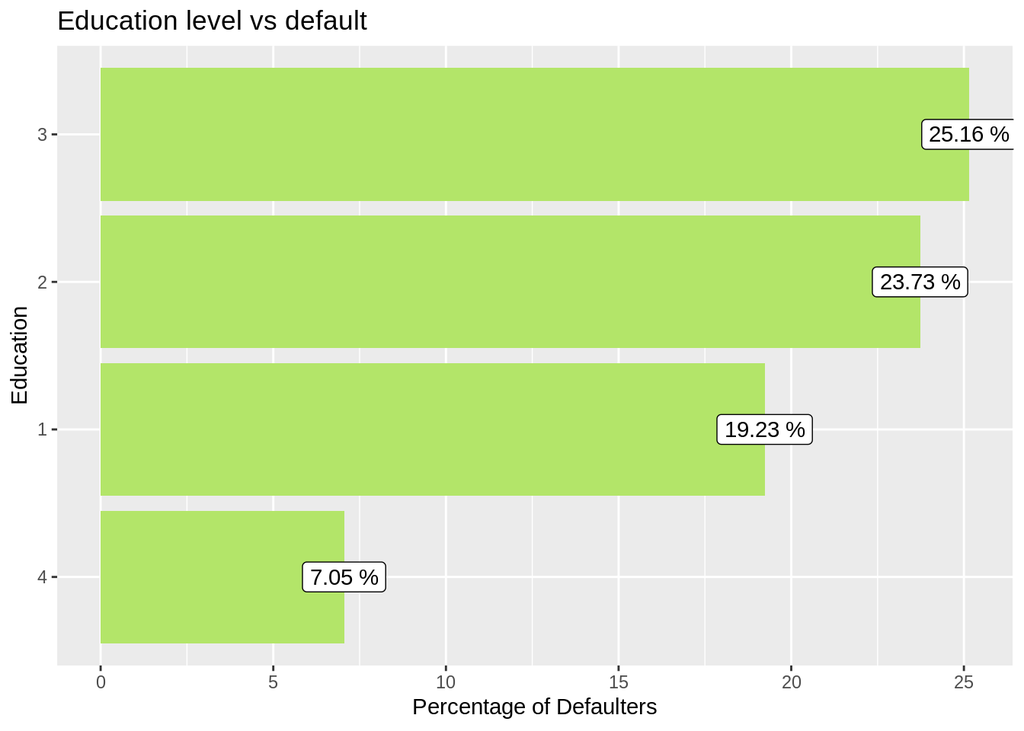

```r
# Bar Graph
ggplot(data = default_count_perc, mapping = aes(x = reorder(level, percentage), y = percentage)) +
  geom_bar(stat = "identity", fill = "#b3e569") +
  coord_flip() +
  xlab("Education") +
  ylab("Percentage of Defaulters") +
  ggtitle("Education level vs default") +
  geom_label(label = paste(default_count_perc$percentage, "%"))
```